# EDA (1)

## Connecting to drive

```python
from google.colab import drive

drive.mount("/content/Drive")
```

```python
import os

# Mount your Google Drive to access files stored there
drive.mount('/content/drive')

# Replace 'your_file_name.csv' with the actual name of your file.
file_name = 'Cell_Phones_and_Accessories_5.json'

# Set the root directory to your Google Drive
root_dir = '/content/drive/My Drive/'

# Function to recursively search for the file in all directories and subdirectories
def find_file(directory):
    for item in os.listdir(directory):
        item_path = os.path.join(directory, item)
        if os.path.isfile(item_path) and item == file_name:
            return directory
        elif os.path.isdir(item_path):
            result = find_file(item_path)
            if result:
                return result
    return None

# Call the function to find the file directory
file_directory = find_file(root_dir)

# Print the file directory
if file_directory:
    print("File directory:", file_directory)
else:
    print("File not found in Google Drive.")
```

```
File directory: /content/drive/My Drive/midterm (1)/dataset
```

```python
os.chdir('/content/drive/My Drive/midterm (1)/dataset')
```

## Importing required libraries

```python
#Basic libraries
import pandas as pd
import numpy as np


#NLTK libraries
import nltk
import re
import string
from wordcloud import WordCloud,STOPWORDS
from nltk.stem.porter import PorterStemmer
from sklearn.feature_extraction.text import TfidfVectorizer

#Visualization libraries
import matplotlib.pyplot as plt
from matplotlib import rcParams
import seaborn as sns
from textblob import TextBlob
from plotly import tools
import plotly.graph_objs as go
from plotly.offline import iplot
%matplotlib inline

#Ignore warnings
import warnings
warnings.filterwarnings('ignore')

#Other miscellaneous libraries
from scipy import interp
from itertools import cycle
import cufflinks as cf
from collections import defaultdict
from collections import Counter
from imblearn.over_sampling import SMOTE
```

## Reading the dataset

```python
# Read the JSON file and convert it to DataFrame
df = pd.read_json('Cell_Phones_and_Accessories_5.json', lines=True)
```

```python
df.head(2)
```

|  | reviewerID | asin | reviewerName | helpful | reviewText | overall | summary | unixReviewTime | reviewTime |
| --- | --- | --- | --- | --- | --- | --- | --- | --- | --- |
| 0 | A30TL5EWN6DFXT | 120401325X | christina | [0, 0] | They look good and stick good! I just don't li... | 4 | Looks Good | 1400630400 | 05 21, 2014 |
| 1 | ASY55RVNIL0UD | 120401325X | emily l. | [0, 0] | These stickers work like the review says they ... | 5 | Really great product. | 1389657600 | 01 14, 2014 |

### Dataset Details

This file has reviewer ID , User ID, Reviewer Name, Reviewer text, helpful, Summary(obtained from Reviewer text),Overall Rating on a scale 5, Review time

Description of columns in the file:

- reviewerID - ID of the reviewer, e.g. A2SUAM1J3GNN3B
- asin - ID of the product, e.g. 0000013714
- reviewerName - name of the reviewer
- helpful - helpfulness rating of the review, e.g. 2/3
- reviewText - text of the review
- overall - rating of the product
- summary - summary of the review
- unixReviewTime - time of the review (unix time)
- reviewTime - time of the review (raw)

## EDA

```python
df.info()
```

```
<class 'pandas.core.frame.DataFrame'>
RangeIndex: 194439 entries, 0 to 194438
Data columns (total 9 columns):
 #   Column          Non-Null Count   Dtype
---  ------          --------------   -----
 0   reviewerID      194439 non-null  object
 1   asin            194439 non-null  object
 2   reviewerName    190920 non-null  object
 3   helpful         194439 non-null  object
 4   reviewText      194439 non-null  object
 5   overall         194439 non-null  int64
 6   summary         194439 non-null  object
 7   unixReviewTime  194439 non-null  int64
 8   reviewTime      194439 non-null  object
dtypes: int64(2), object(7)
memory usage: 13.4+ MB
```

## Creating 'sentiment' column

This is an important preprocessing phase, we are deciding the outcome column (sentiment of review) based on the overall score. If the score is greater than 3, we take that as positive and if the value is less than 3 it is negative If it is equal to 3, we take that as neutral sentiment

```python
#Figuring out the distribution of categories
df['overall'].value_counts()
```

```
5    108664
4     39993
3     21439
1     13279
2     11064
Name: overall, dtype: int64
```

```python
def f(row):

    '''This function returns sentiment value based on the overall ratings from the user'''

    if row['overall'] == 3.0:
        val = 'Neutral'
    elif row['overall'] == 1.0 or row['overall'] == 2.0:
        val = 'Negative'
    elif row['overall'] == 4.0 or row['overall'] == 5.0:
        val = 'Positive'
    else:
        val = -1
    return val
```

```python
#Applying the function in our new column
df['sentiment'] = df.apply(f, axis=1)
df.head()
```

|  | reviewerID | asin | reviewerName | helpful | reviewText | overall | summary | unixReviewTime | reviewTime | sentiment |
| --- | --- | --- | --- | --- | --- | --- | --- | --- | --- | --- |
| 0 | A30TL5EWN6DFXT | 120401325X | christina | [0, 0] | They look good and stick good! I just don't li... | 4 | Looks Good | 1400630400 | 05 21, 2014 | Positive |
| 1 | ASY55RVNIL0UD | 120401325X | emily l. | [0, 0] | These stickers work like the review says they ... | 5 | Really great product. | 1389657600 | 01 14, 2014 | Positive |
| 2 | A2TMXE2AFO7ONB | 120401325X | Erica | [0, 0] | These are awesome and make my phone look so st... | 5 | LOVE LOVE LOVE | 1403740800 | 06 26, 2014 | Positive |
| 3 | AWJ0WZQYMYFQ4 | 120401325X | JM | [4, 4] | Item arrived in great time and was in perfect ... | 4 | Cute! | 1382313600 | 10 21, 2013 | Positive |
| 4 | ATX7CZYFXI1KW | 120401325X | patrice m rogoza | [2, 3] | awesome! stays on, and looks great. can be use... | 5 | leopard home button sticker for iphone 4s | 1359849600 | 02 3, 2013 | Positive |

```python
df['sentiment'].value_counts()
```

```
Positive    148657
Negative     24343
Neutral      21439
Name: sentiment, dtype: int64
```

### Handling time column

Here we have an unusual review time column which has date and year, once we split both we will split the date further into month and date.

```python
# new data frame which has date and year
new = df["reviewTime"].str.split(",", n = 1, expand = True)

# making separate date column from new data frame
df["date"]= new[0]

# making separate year column from new data frame
df["year"]= new[1]

df=df.drop(['reviewTime'], axis=1)
df.head()
```

|  | reviewerID | asin | reviewerName | helpful | reviewText | overall | summary | unixReviewTime | sentiment | date | year |
| --- | --- | --- | --- | --- | --- | --- | --- | --- | --- | --- | --- |
| 0 | A30TL5EWN6DFXT | 120401325X | christina | [0, 0] | They look good and stick good! I just don't li... | 4 | Looks Good | 1400630400 | Positive | 05 21 | 2014 |
| 1 | ASY55RVNIL0UD | 120401325X | emily l. | [0, 0] | These stickers work like the review says they ... | 5 | Really great product. | 1389657600 | Positive | 01 14 | 2014 |
| 2 | A2TMXE2AFO7ONB | 120401325X | Erica | [0, 0] | These are awesome and make my phone look so st... | 5 | LOVE LOVE LOVE | 1403740800 | Positive | 06 26 | 2014 |
| 3 | AWJ0WZQYMYFQ4 | 120401325X | JM | [4, 4] | Item arrived in great time and was in perfect ... | 4 | Cute! | 1382313600 | Positive | 10 21 | 2013 |
| 4 | ATX7CZYFXI1KW | 120401325X | patrice m rogoza | [2, 3] | awesome! stays on, and looks great. can be use... | 5 | leopard home button sticker for iphone 4s | 1359849600 | Positive | 02 3 | 2013 |

```python
# Splitting the date
new1 = df["date"].str.split(" ", n = 1, expand = True)

# adding month to the main dataset
df["month"]= new1[0]

# adding day to the main dataset
df["day"]= new1[1]

df=df.drop(['date'], axis=1)
df.head()
```

|  | reviewerID | asin | reviewerName | helpful | reviewText | overall | summary | unixReviewTime | sentiment | year | month | day |
| --- | --- | --- | --- | --- | --- | --- | --- | --- | --- | --- | --- | --- |
| 0 | A30TL5EWN6DFXT | 120401325X | christina | [0, 0] | They look good and stick good! I just don't li... | 4 | Looks Good | 1400630400 | Positive | 2014 | 05 | 21 |
| 1 | ASY55RVNIL0UD | 120401325X | emily l. | [0, 0] | These stickers work like the review says they ... | 5 | Really great product. | 1389657600 | Positive | 2014 | 01 | 14 |
| 2 | A2TMXE2AFO7ONB | 120401325X | Erica | [0, 0] | These are awesome and make my phone look so st... | 5 | LOVE LOVE LOVE | 1403740800 | Positive | 2014 | 06 | 26 |
| 3 | AWJ0WZQYMYFQ4 | 120401325X | JM | [4, 4] | Item arrived in great time and was in perfect ... | 4 | Cute! | 1382313600 | Positive | 2013 | 10 | 21 |
| 4 | ATX7CZYFXI1KW | 120401325X | patrice m rogoza | [2, 3] | awesome! stays on, and looks great. can be use... | 5 | leopard home button sticker for iphone 4s | 1359849600 | Positive | 2013 | 02 | 3 |

### Finding the helpfulness of the review

From the main dataframe we can see the helpful feature with values in list [a,b] format. It says that a out of b people found that review helpful. But with that format, it could not add value to the machine learning model and it will be difficult to decrypt the meaning for the machine. So I have planned to create helpful_rate feature which returns a/b value from [a,b]. The following codeblock contains the complete processing step. I have added comments on what's happenening in each code. Unhide to see the code

```python
# Convert the "helpful" column to strings
df["helpful"] = df["helpful"].astype(str)

# Function to calculate the helpful rate
def calculate_helpful_rate(row):
    numbers = row.strip("[]").split(", ")
    a, b = map(int, numbers)
    if b != 0:
        return round(a / b, 2)  # Calculate the division and round to 2 decimal places
    else:
        return 0.0  # Return 0.0 when both values are 0

# Apply the function to create the "helpful_rate" column
df["helpful_rate"] = df["helpful"].apply(calculate_helpful_rate)
```

We have successfully created the helpful_rate column through processing steps. Let's look at the values

```python
df.head(4)
```

|  | reviewerID | asin | reviewerName | helpful | reviewText | overall | summary | unixReviewTime | sentiment | year | month | day | helpful_rate |
| --- | --- | --- | --- | --- | --- | --- | --- | --- | --- | --- | --- | --- | --- |
| 0 | A30TL5EWN6DFXT | 120401325X | christina | [0, 0] | They look good and stick good! I just don't li... | 4 | Looks Good | 1400630400 | Positive | 2014 | 05 | 21 | 0.0 |
| 1 | ASY55RVNIL0UD | 120401325X | emily l. | [0, 0] | These stickers work like the review says they ... | 5 | Really great product. | 1389657600 | Positive | 2014 | 01 | 14 | 0.0 |
| 2 | A2TMXE2AFO7ONB | 120401325X | Erica | [0, 0] | These are awesome and make my phone look so st... | 5 | LOVE LOVE LOVE | 1403740800 | Positive | 2014 | 06 | 26 | 0.0 |
| 3 | AWJ0WZQYMYFQ4 | 120401325X | JM | [4, 4] | Item arrived in great time and was in perfect ... | 4 | Cute! | 1382313600 | Positive | 2013 | 10 | 21 | 1.0 |

0.00 indicates that the review hasn't been much helpful and 1.00 indicates that the review has been very helpful

```python
df['helpful_rate'].value_counts()
```

```
0.00    150799
1.00     26504
0.50      5298
0.67      2332
0.75      1456
         ...
0.19         2
0.51         2
0.01         1
0.34         1
0.49         1
Name: helpful_rate, Length: 100, dtype: int64
```

### Visualizations

##### Sentiments vs Helpful rate

First lets look whether there any relationship between sentiment of review and helpfulness of it

```python
pd.DataFrame(df.groupby('sentiment')['helpful_rate'].mean())
```

| sentiment | helpful_rate |
| --- | --- |
| Negative | 0.205465 |
| Neutral | 0.167881 |
| Positive | 0.194686 |

From the table we can see that the mean of of helpful rate is higher for any negative reviews than neutral and positive reviews. These mean value might have been influenced by the 0 values in helpful rates. Lets check how it is distributed through violin plot

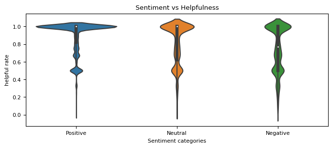

```python
#plot layout
plt.rcParams.update({'font.size': 8})
rcParams['figure.figsize'] = 8,3

# Creating dataframe and removing 0 helpfulrate records
senti_help= pd.DataFrame(df, columns = ['sentiment', 'helpful_rate'])
senti_help = senti_help[senti_help['helpful_rate'] != 0.00]

#Plotting phase
sns.violinplot( x=senti_help["sentiment"], y=senti_help["helpful_rate"])
plt.title('Sentiment vs Helpfulness')
plt.xlabel('Sentiment categories')
plt.ylabel('helpful rate')
plt.show()
```

Insights:

From the plot we can declare that more number of positive reviews are having high helpful rate. We got deceived by the mean value, it's better to look at a plot rather than taking some measures of central tendency under such situation.

### Year vs Sentiment count

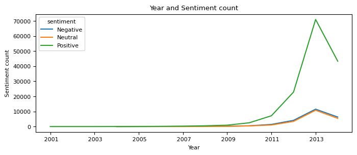

```python
df.groupby(['year','sentiment'])['sentiment'].count().unstack().plot(legend=True)
plt.title('Year and Sentiment count')
plt.xlabel('Year')
plt.ylabel('Sentiment count')
plt.show()
```

Insights:

From the plot we can clearly see the rise in positive reviews from 2010. Reaching its peak around 2013 and there is a dip in 2014, All the review rates were dropped at this time. Negative and neutral reviews are very low as compared to the positive reviews.

### Day of month vs Reviews count

Let's check if there are any relationship between reviews and day of month

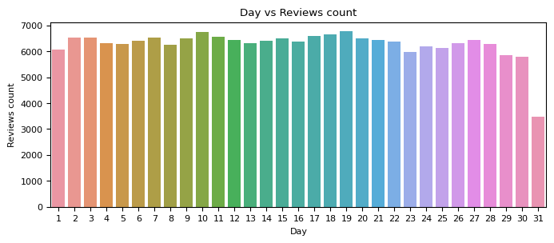

```python
#Creating a dataframe
day=pd.DataFrame(df.groupby('day')['reviewText'].count()).reset_index()
day['day']=day['day'].astype('int64')
day.sort_values(by=['day'])

#Plotting the graph
sns.barplot(x="day", y="reviewText", data=day)
plt.title('Day vs Reviews count')
plt.xlabel('Day')
plt.ylabel('Reviews count')
plt.show()
```

### Wordcloud reviews

Let's look at the word cloud of positive, neutral and negative reviews

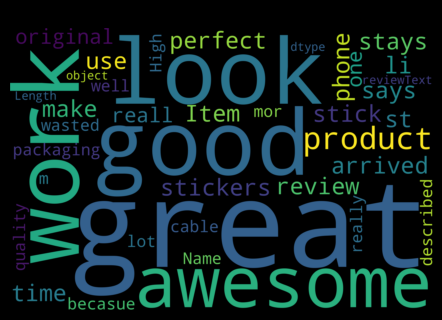

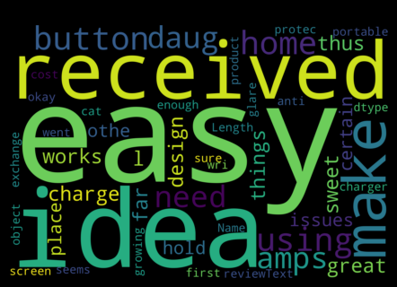

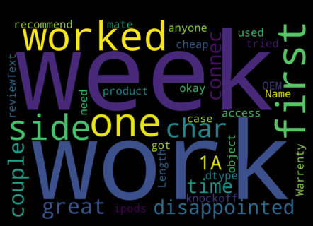

```python
# Iterate through each sentiment class
sentiments = df["sentiment"].unique()
for sentiment in sentiments:
    text = df[df["sentiment"] == sentiment]["reviewText"]

    wordcloud = WordCloud(
        width=3000,
        height=2000,
        background_color='black',
        stopwords=STOPWORDS).generate(str(text))

    fig = plt.figure(
        figsize=(8, 3),
        facecolor='k',
        edgecolor='k')

    plt.imshow(wordcloud, interpolation='bilinear')
    plt.title(f"Word Cloud for {sentiment.capitalize()} Sentiment")
    plt.axis('off')
    plt.tight_layout(pad=0)

    print("\n")
    print("\n")

    # Show the plot for the current sentiment class
    plt.show()
```

Most of the neutral review words are focussed on the products and how can they be improved.